# Exploration de la base JOCAS

Author

Claude Grasland

```r
library(knitr)
## Global options
options(max.print="80")
opts_chunk$set(echo=TRUE,
               cache=FALSE,
               prompt=FALSE,
               tidy=FALSE,
               comment=NA,
               message=FALSE,
               warning=FALSE,
               options(scipen=999))
opts_knit$set(width=75)

# Packages utilitaires
library(dplyr)
library(data.table)
# Packages graphiques
library(ggplot2)

#packages cartographiques
library(sf)
library(mapsf)

# Appel d'API
library(jsonlite)
```

Au cours de cette première étape, nous allons prendre connaissance d’un fichier de très grande taille issu de la base JOCAS et effectuer un diagnostic de la qualité des données et des possibilités de traitement qu’elles offrent.

## Importation des données

### Charger le fichier

```r
base<-readRDS("data/jocas/OffresPE_Geo_2020.Rdata")
```

Reamrquer que le fichier se charge rapidement car il a été sauvegardé au format interne de R (.Rdata ou .RDS).

### Vérifier son type et ses dimensions

```r
dim(base)
```

```
[1] 3727995      10
```

```r
class(base)
```

```
[1] "data.frame"
```

Le tableau comporte 3.7 millions de lignes et 10 variables ce qui le classe dans la catégorie des **Big Data**, définie arbirairement comme une base de données comportant plus d’un million d’individus.

### Examiner le type des variables

```r
str(base)
```

```
'data.frame':   3727995 obs. of  10 variables:
 $ date_sitePublicationDay: Date, format: "2020-01-01" "2020-01-01" ...
 $ location_zipcode       : Factor w/ 6593 levels "01000","01090",..: 5570 864 864 4122 4036 2183 5062 NA 2386 4677 ...
 $ location_departement   : Factor w/ 116 levels "","01","02","03",..: 91 18 18 70 70 40 84 1 43 77 ...
 $ location_country       : Factor w/ 96 levels "","Afrique du Sud",..: 1 1 1 1 1 1 1 1 1 1 ...
 $ salary_hourly_mean     : num  13.8 12.9 12.9 10.5 10 ...
 $ job_ROME_code          : Factor w/ 532 levels "","A1101","A1201",..: 160 488 78 104 373 426 373 372 51 315 ...
 $ entrepriseSecteur_NAF21: Factor w/ 20 levels "","C","D","E",..: 5 13 13 13 16 13 19 19 1 14 ...
 $ entrepriseSecteur_NAF88: Factor w/ 87 levels "1","2","3","6",..: 38 68 68 68 77 70 85 85 NA 73 ...
 $ contractType           : Factor w/ 12 levels "CCE","CDD","CDI",..: 2 9 9 2 3 3 2 2 3 2 ...
 $ contractDuration_value : num  130 390 130 260 NA NA 130 173 NA 130 ...
```

Il existe une variable de type *Date*, deux variables de type *numeric* et 7 variables de type *factor*. Le stockage des variable sous la forme *factor* plutôt que *character* a été utilisé pour réduire la taille du fichier .RDS. En effet un facteur ne stocke les étiquettes qu’une seule fois puis note le niveau du facteur 1…n ce qui prend moins de place que le stockage de chaînes de caractères comportant plusieurs caractères.

### Définir les variables

On se reporte au fichier pdf `Description_variables_Jocas_Dedup.pdf` pour trouver la définiton précise de chacun des dix indicateurs sélectionnés :

- **date_sitePublicationDay**: Date de publication de l’offre telle que renseignée sur le site. C’est une information fournie par le site contrairement aux variables précédentes. Ce champ peut être vide. Format : %Y-%m-%d
- **location_zipcode** : Code postal du lieu de travail. C’est le code postal indiqué par le site, si cette donnée est disponible. Sinon la Dares effectue un matching entre « location_label » et les libellés de communes françaises pour retrouver le code postal. Parfois le matching est ambigüe (plusieurs codes postaux pour un même libellé), dans ce cas le code postal reste vide.
- **location_departement** : Département du lieu de travail (départements français ou DOM-TOM). Le département « 99 » correspond à l’étranger.
- **location_country** : Si l’offre est à l’étranger et que le pays étranger est connu, nom du pays étranger. Cette variable est généralement vide car la majorité des offres sont en France.
- **salary_hourly_mean** :Salaire horaire moyen. Calcul selon la métoholodie dans le document methodologique
- **job_ROME_code** : Code métier selon la nomenclature ROME de Pôle emploi. Le code ROME est codé automatiquement à partir de l’intitulé de l’offre (variable « job_title »), grâce à un algorithme décrit dans ce document. Pour l’API Pôle emploi, les offres contiennent déjà le code ROME, codé par Pôle emploi.
- **entrepriseSecteur_NAF21**: Secteur d’activité de l’entreprise selon la nomenclature NAF de l’Insee, au niveau A21.
- **entrepriseSecteur_NAF88**: Secteur d’activité de l’entreprise selon la nomenclature NAF de l’Insee, au niveau A88.
- **contractType** :Type de contrat proposé, tel que renseigné dans les champs structurés des offres. Les catégories ne sont pas homogènes selon les sites. Dans certains cas nous pouvons pas distinguer entre plusieurs contrats. Les differentes valeurs possibles sont : CDI ; CDD ; MIS [Mission d’Intérim] ; Apprentissage ; Alternance ; Independant ; Independant/Franchise ; Stage/Alternance ; Stage ; Apprentissage/Alternance ; CDD/MIS ; CDI/MIS ; Franchise ; Titulaire de la fonction publique ; Contrat étranger ; Contrat de professionnalisation ; VIE ; VIA ; Bénévolat ; CDS [CDD Sénior] ; SAI [Saisonnier] ; CCE [Profession commerciale]; REP [Reprise d’entreprise] ; TTI [Contrat travail temporaire insertion] ; DDI [Contrat durée déterminée insertion] ; DIN [CDI Intérimaire] ; Intermittent ; Contrat d’usage ;Contractuel de la fonction publique ; Avis de concours **contractDuration_value** : Durée moyenne du contrat, exprimée en jours.

## Analyse, recodage et enrichissement des variables

Au cours de cette étape on va analyser, enrichir et recoder les variables qui nous intéressent. On en profitera pour leur donner des noms plus courts.

### La variable **date** (date_sitePublicationDay)

On examine les paramètres de la distribution avec summary()

```r
base$date <-base$date_sitePublicationDay
summary(base$date)
```

```
        Min.      1st Qu.       Median         Mean      3rd Qu.         Max.
"2020-01-01" "2020-03-11" "2020-06-30" "2020-06-22" "2020-09-18" "2020-12-31"
```

- Y-a-t-il des valeurs manqantes ? : NON
- Y-a-t-il des valeurs aberrantes ? : NON

On réalise un graphique rapide avec ggplot pour examiner la forme de la distribution du nombre de publications par jour :

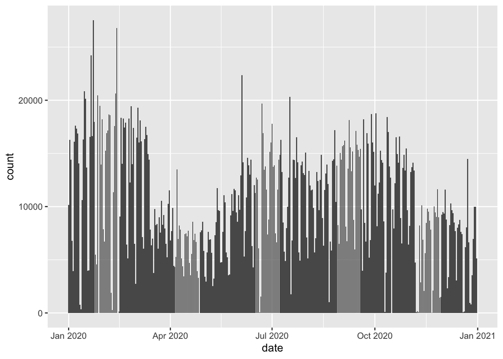

```r
ggplot(base) + aes(x=date) + geom_bar()
```

On verra oar la suite que cette donnée peut s’agréger en semaines, mois ou trimestre.

### La variable **dep** (*location_departement*)

On crée la variable et on examine sa distribution :

```r
base$dep_code<-base$location_departement
summary(base$location_departement)
```

```
           75     69     92     33     13     59     44     31     38     35
237206 175777 164630 134828 122942 115264 111966 108137  91937  79044  72542
    78     67     34     06     77     94     74     91     93     85     83
 70602  67193  62340  60364  58896  56604  54366  54173  53314  53284  52975
    49     76     29     57     56     62     95     73     45     17     14
 51456  48790  48777  45880  44911  43774  42164  38833  38459  37900  36657
    64     01     42     37     54     68     63     60     21     26     22
 36642  36555  35287  34576  34572  33736  33440  32915  32661  32504  30828
    84     51     25     30     72     71     50     27     47     79     40
 29883  29608  29362  28605  27769  24667  24050  22235  21952  21779  21720
    86     80     28     24     16     66     11     89     41     88     81
 20313  19858  18850  18743  18649  18182  17558  17556  17383  17368  16806
    53     02     18    974     87     10     65     12     82     39     19
 16615  16069  14413  13884  13735  13334  12983  12875  12820  11943  11791
    07     61     03
 11764  11362  10887
 [ reached getOption("max.print") -- omitted 20 entries ]
```

```r
table(base$location_departement)
```

```
           01     02     03     04     05     06     07     08     09      1
237206  36555  16069  10887   8085   8170  60364  11764   9084   7372    101
    10     11     12     13     14     15     16     17     18     19      2
 13334  17558  12875 115264  36657   5694  18649  37900  14413  11791     26
    21     22     23     24     25     26     27     28     29     2A     2B
 32661  30828   4391  18743  29362  32504  22235  18850  48777   7011   6337
     3     30     31     32     33     34     35     36     37     38     39
    25  28605  91937   9583 122942  62340  72542  10012  34576  79044  11943
     4     40     41     42     43     44     45     46     47     48     49
    16  21720  17383  35287   7593 108137  38459   9732  21952   3860  51456
     5     50     51     52     53     54     55     56     57     58     59
     8  24050  29608   7134  16615  34572   7018  44911  45880   8170 111966
     6     60     61     62     63     64     65     66     67     68     69
   145  32915  11362  43774  33440  36642  12983  18182  67193  33736 164630
     7     70     71
    16   7304  24667
 [ reached getOption("max.print") -- omitted 36 entries ]
```

- Y-a-t-il des valeurs manqantes ? : OUI
- Y-a-t-il des valeurs aberrantes ? : OUI

Ce fichier appelle plusieurs corrections. On supposera ici qu’on ne veut garder que les départements de France métropolitaine. Quelle solution simple permet de les repérer ?

```r
base <- base %>% mutate( dep_code = as.character(location_departement),
                         dep_code = case_when(dep_code=="99" ~ NA,
                                           nchar(dep_code)==2~ dep_code,
                                           .default = NA))
table(base$dep_code)
```

```
    01     02     03     04     05     06     07     08     09     10     11
 36555  16069  10887   8085   8170  60364  11764   9084   7372  13334  17558
    12     13     14     15     16     17     18     19     21     22     23
 12875 115264  36657   5694  18649  37900  14413  11791  32661  30828   4391
    24     25     26     27     28     29     2A     2B     30     31     32
 18743  29362  32504  22235  18850  48777   7011   6337  28605  91937   9583
    33     34     35     36     37     38     39     40     41     42     43
122942  62340  72542  10012  34576  79044  11943  21720  17383  35287   7593
    44     45     46     47     48     49     50     51     52     53     54
108137  38459   9732  21952   3860  51456  24050  29608   7134  16615  34572
    55     56     57     58     59     60     61     62     63     64     65
  7018  44911  45880   8170 111966  32915  11362  43774  33440  36642  12983
    66     67     68     69     70     71     72     73     74     75     76
 18182  67193  33736 164630   7304  24667  27769  38833  54366 175777  48790
    77     78     79
 58896  70602  21779
 [ reached getOption("max.print") -- omitted 16 entries ]
```

### Ajout des codes, noms et fonds de carte des départements et régions

Récupérer un fonds de carte donnant le contour simplifié des départements de France métropolitaine et enregistrez-le

https://public.opendatasoft.com/explore/dataset/contours-geographiques-tres-simplifies-des-departements-2019/information/

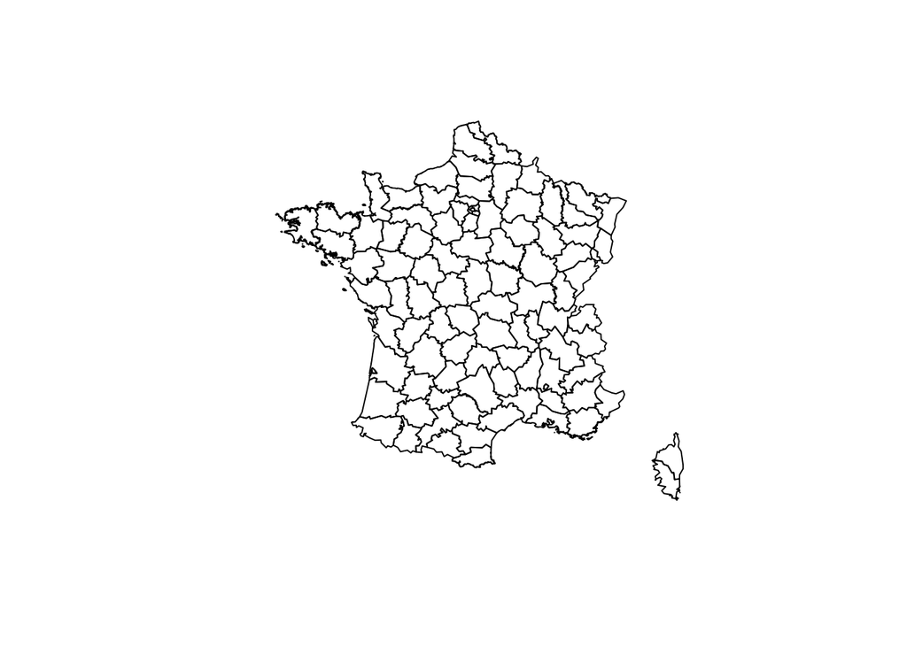

```r
myurl <- "https://public.opendatasoft.com/api/explore/v2.1/catalog/datasets/contours-geographiques-tres-simplifies-des-departements-2019/exports/geojson?lang=fr&timezone=Europe%2FBerlin"
map <- st_read(myurl)
map <- map %>% filter(nchar(insee_dep)==2) %>%st_transform(2154)
plot(map$geometry)
```

Ne conserver que les variables utiles et les renommer :

```r
map_dep <- map %>% select(dep_code = insee_dep,
                      dep_nom = nom_dep_min,
                      reg_code = insee_reg,
                      reg_nom = region_min)
saveRDS(map_dep,"data/jocas/map_dep.RDS")
```

Agréger par région et sauvegarder :

```r
map_reg <- map_dep %>% group_by(reg_code, reg_nom) %>%
                       summarise()
saveRDS(map_reg,"data/jocas/map_reg.RDS")
```

Faire une jointure entre la base des annonces et les codes départementaux ou régionaux.

```r
tabcode <-st_drop_geometry(map_dep)
base <- left_join(base,tabcode)
```

Réalisez une carte du nombre d’annonces par département.

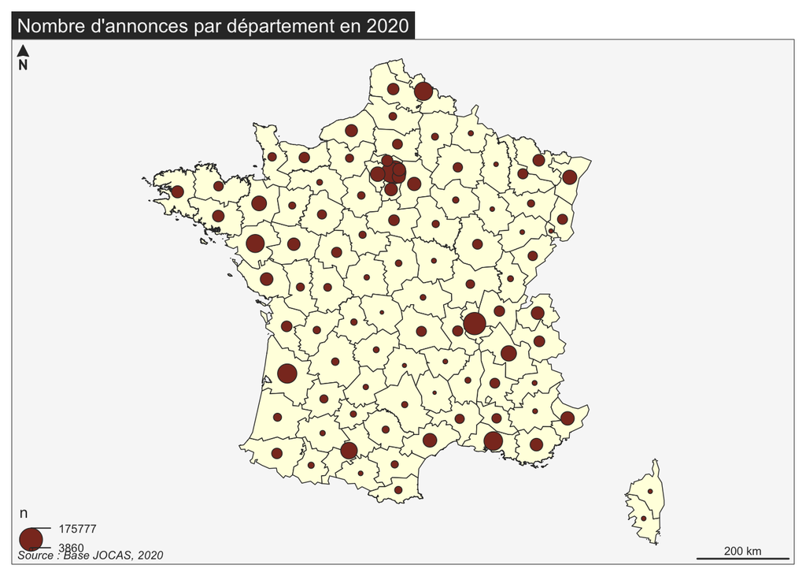

```r
# Agrégation
don<- base %>%   group_by(dep_code) %>%
                 count()
# Jointure
mapdon<-map_dep %>% left_join(don)

# Carte
mf_map(mapdon, type="base",
       col="lightyellow")
mf_map(mapdon, type="prop",
       inches=0.1,
       var ="n",
       add=TRUE)
mf_layout("Nombre d'annonces par département en 2020",
          frame=T,
          credits = "Source : Base JOCAS, 2020")
```

Réalisez une carte du nombre d’annonces par région

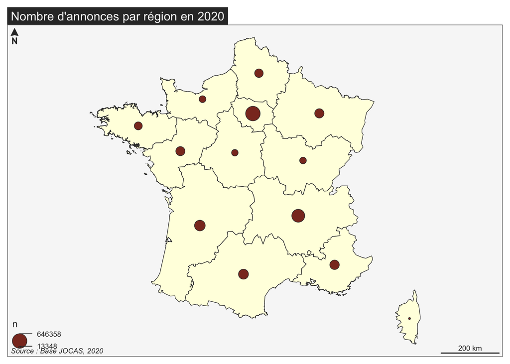

```r
# Agrégation
don<- base %>%   group_by(reg_code) %>%
                 count()
# Jointure
mapdon<-map_reg %>% left_join(don)

# Carte
mf_map(mapdon, type="base",
       col="lightyellow")
mf_map(mapdon, type="prop",
       inches=0.1,
       var ="n",
       add=TRUE)
mf_layout("Nombre d'annonces par région en 2020",
          frame=T,
          credits = "Source : Base JOCAS, 2020")
```

### La variable **job** (*job_ROME_Code*)

On examine la distribution de la variable décrivant le type d’activité proposée dans l’annonce.

```r
base$job<-base$job_ROME_code
summary(base$job)
```

```
 K1303  M1203  C1504  J1506  K1304  K1302  I1304  J1501  N1103  N4101  M1805
158656 102983  91175  89911  88992  87821  73391  73257  60914  60033  58585
 G1602  I1604  D1401  J1102  D1403  K2204  D1407  K2107  F1106  F1603  M1202
 54650  54131  52608  46972  43881  43293  43176  38768  38186  36977  36519
 D1402  D1507  G1803  F1602  F1703  M1607  F1201  D1106  F1202  N1101  I1203
 36481  33272  32786  30563  30528  28230  27906  27889  25218  24752  23436
 N1303  D1212  D1408  H1206  M1802  H2102  A1203  H2502  D1301  H2206  N1105
 22813  21687  21208  21023  20491  20413  20237  20050  20010  19977  19861
 F1704  F1607  H2903  I1306  G1603  K2503  K2111  D1406  N4105  M1803  F1302
 19811  19737  19658  19462  19227  19212  18888  18684  18648  18505  18157
 D1101  D1102  M1501  M1707  M1204  K1207  M1806  I1307  J1103  H3302  G1203
 17877  17753  17583  17043  16620  16495  16357  16316  16102  15780  15367
 M1502  M1601  F1604  H2913  I1401  H1502  K1903  D1502  C1102  I1606  F1610
 14952  14897  14852  14713  14504  14055  13731  13667  13561  13465  13440
 H1203  K1301  M1604
 13305  13250  12922
 [ reached getOption("max.print") -- omitted 20 entries ]
```

```r
table(base$job)
```

```
        A1101  A1201  A1202  A1203  A1204  A1205  A1301  A1302  A1303  A1401
   410   1942   1945    576  20237    101    267   2041   1066   1359   2763
 A1402  A1403  A1404  A1405  A1406  A1407  A1408  A1409  A1410  A1411  A1412
   910    435    492   4680     16    773    333    527    310    381    767
 A1413  A1414  A1415  A1416  A1417  A1501  A1502  A1503  A1504  B1101  B1201
  1152   3073     58   3385     34    395    201    104    204     43     45
 B1301  B1302  B1303  B1401  B1402  B1501  B1601  B1602  B1603  B1604  B1801
   396    200     34     11      9     21    250     29    392     93      1
 B1802  B1803  B1804  B1805  B1806  C1101  C1102  C1103  C1104  C1105  C1106
   374   1486     47    106    329    263  13561   2005    335    989    719
 C1107  C1108  C1109  C1110  C1201  C1202  C1203  C1204  C1205  C1206  C1207
   433    187   8206    629   1690   1069    619     61   6824  12269    365
 C1301  C1302  C1303  C1401  C1501  C1502  C1503  C1504  D1101  D1102  D1103
   323   2881    185    755   5397   4274   7506  91175  17877  17753   1373
 D1104  D1105  D1106
 10174   4494  27889
 [ reached getOption("max.print") -- omitted 452 entries ]
```

- Y-a-t-il des valeurs manquantes ? : OUI
- Y-a-t-il des valeurs aberrantes ? : Difficile à dire

Pour savoir s’il y a des valeurs manquantes on a besoin de récupérer la liste des codes ROME que l’onva trouver sur le site suivant : https://public.opendatasoft.com/explore/?sort=modified&q=ROME+code

```r
myurl <- "https://public.opendatasoft.com/api/explore/v2.1/catalog/datasets/pole-emploi-rome-arborescence-principale/exports/json?lang=fr&timezone=Europe%2FBerlin"
code<-fromJSON(myurl)
```

On simplifie le tableau pour ne garder que les trois niveaux de code ROME et leur définition. On élimine la correspondance avec la NAF et on sauvegarde le tableau.

```r
code_rome<-code %>%   mutate(job=as.factor(code_rome),
                          job_name=as.factor(libelle),
                          dom =as.factor(domaine_professionnel),
                          dom_name =as.factor(libelle_domaine_professionnel),
                          big_dom = as.factor(grand_domaine),
                          big_dom_name = as.factor(libelle_grand_domaine)) %>%
                  select(job,
                         job_name,
                         dom,
                         dom_name,
                         big_dom,
                         big_dom_name) %>%
                    filter(duplicated(job)==F)

saveRDS(code_rome,"data/jocas/code_rome.RDS")
head(code_rome)
```

```
    job
1 I1201
2 I1203
3 I1301
4 I1302
5 I1304
6 I1305
                                                                                            job_name
1                                                   Chef d'équipe en mobilier urbain et publicitaire
2                                                            Agent / Agente d'entretien des piscines
3 Mécanicien-électricien monteur-régleur / Mécanicienne-électricienne monteuse-régleuse d'ascenseurs
4                                        Agent / Agente de maintenance automaticien / automaticienne
5                                          Chef d'atelier d'entretien et de maintenance industrielle
6                                        Agent / Agente d'intervention sur équipements électroniques
  dom                                          dom_name big_dom
1  12                               Entretien technique       I
2  12                               Entretien technique       I
3  13 Equipements de production, équipements collectifs       I
4  13 Equipements de production, équipements collectifs       I
5  13 Equipements de production, équipements collectifs       I
6  13 Equipements de production, équipements collectifs       I
                 big_dom_name
1 Installation et Maintenance
2 Installation et Maintenance
3 Installation et Maintenance
4 Installation et Maintenance
5 Installation et Maintenance
6 Installation et Maintenance
```

```r
dim(table(code_rome$job))
```

```
[1] 532
```

```r
dim(table(code_rome$dom))
```

```
[1] 26
```

```r
dim(table(code_rome$big_dom))
```

```
[1] 14
```

Comme on peut le voir, la classfication ROME permet de regrouper les métiers à trois niveaux d’agrégation différents :

- **job** : 532 métiers (*ex. I1501 = Alpiniste du bâtiment*)
- **dom** : 26 domaines d’emploi (*ex. I15 = Travaux d’accès difficile*)
- **big_dom** : 14 grands domaines d’emploi (*ex. I = Installation et maintenance*)

On effectue une jointure avec la base principale :

```r
base <-base %>% left_join(code_rome)
```

### La variable **typ** (*contractType*)

Cette variable décrit le type de contrat.

```r
base$typ <-as.factor(base$contractType)
summary(base$typ)
```

```
        CCE         CDD         CDI         CDS         DDI         DIN
      15582      685845     2225920         503        3243        1060
  Franchise Independant         MIS         REP         SAI         TTI
      26088       73010      647602        5634       42870         638
```

- Y-a-t-il des valeurs manquantes ? : NON
- Y-a-t-il des valeurs aberrantes ? : NON

La variable est propre, mais il y aura certainement lieu de procéder à des regroupements. On examinera la question ultérieurement.

### La variable **sal** (*salarly_hourly_mean*)

Il s’agit d’une variable quantitative fournissant une estimation du salaire horaire basée sur les informations données dans l’annonce. Comporte-te-elle des valeurs manquantes ou aberrantes ?

```r
base$sal <-base$salary_hourly_mean
tab<-table(is.na(base$sal))
tab
```

```
  FALSE    TRUE
1373171 2354824
```

```r
prop.table(tab)
```

```
    FALSE      TRUE
0.3683404 0.6316596
```

```r
summary(base$sal)
```

```
    Min.  1st Qu.   Median     Mean  3rd Qu.     Max.     NA's
     0.0     10.2     11.5     15.7     14.2 106149.0  2354824
```

- Y-a-t-il des valeurs manquantes ? : OUI (2.3 millions sur 3.7 soit 63%)
- Y-a-t-il des valeurs aberrantes ? : OUI (un salaire de 106149 € de l’heure est peu plausible)

On décide de garder pour l’instant toutes les valeurs. On verra par la suite comment traiter ce problème.

### La variable **dur** (*contractDuration_value*)

Il s’agit à nouveau d’une variable quantitative qui a été reconstituée à partir du texte de l’annonce.

```r
base$dur <-base$contractDuration_value
tab<-table(is.na(base$dur))
tab
```

```
  FALSE    TRUE
1374359 2353636
```

```r
prop.table(tab)
```

```
   FALSE     TRUE
0.368659 0.631341
```

```r
summary(base$dur)
```

```
   Min. 1st Qu.  Median    Mean 3rd Qu.    Max.    NA's
    0.0    43.0    87.0   123.7   130.0 22492.0 2353636
```

- Y-a-t-il des valeurs manquantes ? : OUI (2.3 millions sur 3.7 soit 63%)
- Y-a-t-il des valeurs aberrantes ? : OUI (un contrat de 22492 jours soit 61.6 ans est peu probable …)

On décide de garder pour l’instant toutes les valeurs. On verra par la suite comment traiter ce problème.

## Sauvegarde finale du tableau

On retient uniquement les nouvelles variables, on les passe en factor pour réduire la taille et on ne conserve que les annoncespour lesquels on dispose de tous les indicateurs.

```r
## Choix des colonnes
sel <- base %>% select(11:24)

## Passage en facteurs des colonnes de type caractère
sel <- sel %>% mutate(dep_code = as.factor(dep_code),
                      dep_nom = as.factor(dep_nom),
                      reg_code = as.factor(reg_code),
                      reg_nom = as.factor(reg_nom))

## Sauvegarde de la base
saveRDS(sel, "data/jocas/data_clean.RDS")


## Selection des annonces complètes
sel2 <- na.omit(sel)

# Sauvegarde de la base
saveRDS(sel2, "data/jocas/data_clean_complete.RDS")
```